# ODD Analysis

Serhan Suer

Nov 25, 2018

## Introduction

- brand_name: Name of the brand
- auto_dom : Sales amount of domestic automobiles
- auto_imp : Sales amount of imported automobiles
- auto_total : Total sales amount of automobiles
- comm_dom : Sales amount of domestic commercial vehicles
- comm_imp : Sales amount of imported commercial vehicles
- comm_total : Total sales amount of commercial vehicles
- total_dom : Total sales of all domestic product vehicles
- total_imp : Total sales of all imported vehicles
- total_total: Total sales amount of all vehicles
- year : Year
- month : Month

In order to perform a healthy analysis, the dataset has been adjusted in three aspects:

```r
setwd('/Users/serhansuer/Desktop/MEF/Data_Analytics_Essentials/ODD')
raw_data = read_rds('car_data_aggregate.rds')
raw_data = subset(raw_data,subset=brand_name != 'TOPLAM:')
raw_data$brand_name = str_replace(raw_data$brand_name,'ASTON MARTİN','ASTON MARTIN')
raw_data = subset(raw_data, subset=(!startsWith(brand_name, 'ODD')))
asd = select(raw_data, contains('name')) %>%
    arrange(brand_name)
distinct(asd)
```

```
## # A tibble: 49 x 1
##    brand_name
##    <chr>
##  1 ALFA ROMEO
##  2 "ASTON MART\u0130N"
##  3 ASTON MARTIN
##  4 AUDI
##  5 BENTLEY
##  6 BMW
##  7 CHERY
##  8 CITROEN
##  9 DACIA
## 10 DS
## # ... with 39 more rows
```

## First Analysis

First analysis shows that the total sales of 2016, 2017 and 2018 by month.

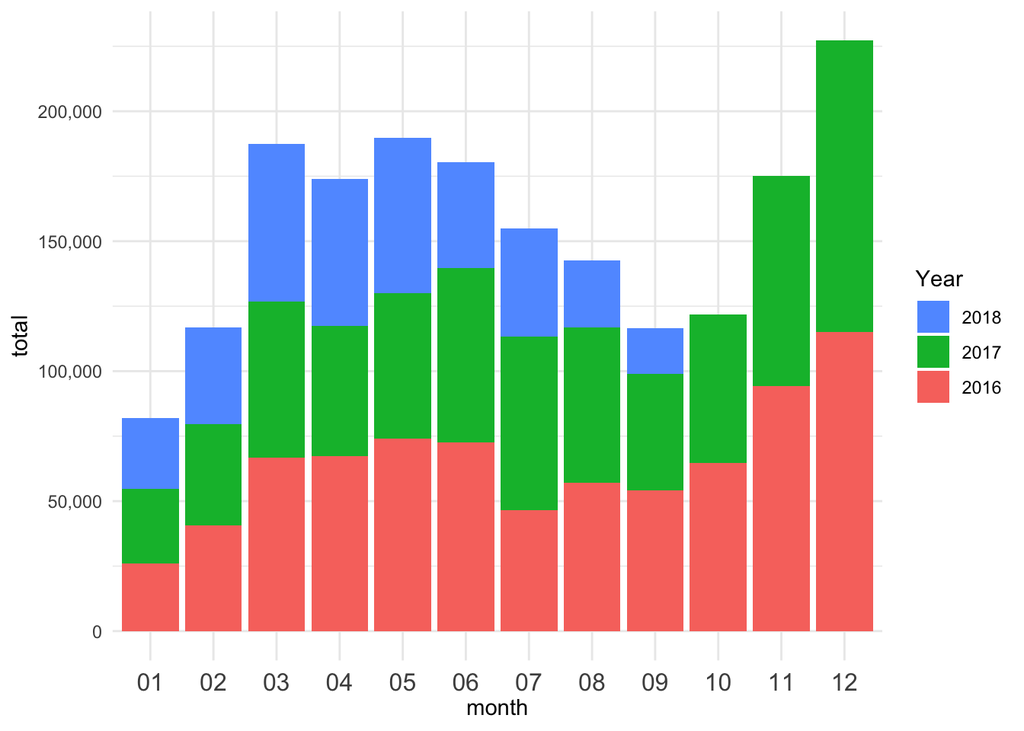

```r
raw_data %>%
  mutate(month=with(raw_data,sprintf("%02d", month)))%>%
  filter(auto_total > 0 & comm_total > 0) %>%
  select(auto_total,comm_total,total_total,year,month) %>%
  group_by(month, year) %>%
  summarize(total = sum(total_total)) %>%
  arrange(desc(total))%>%
  ggplot(aes(x = month, y = total,
  fill = as.character(year))) + geom_bar(stat = "identity", position = position_stack(reverse = TRUE)) + theme_minimal() + theme(legend.position = "right", legend.direction = "vertical",
  axis.text.x = element_text(vjust = 0.5, hjust = 0.5, size = 12)) +
  guides(fill=guide_legend(title="Year", reverse=TRUE)) + scale_y_continuous(labels = scales::comma)
```

## Second Analysis

Second analysis illustrates that the total car sales per year in percantage with a pie chart.

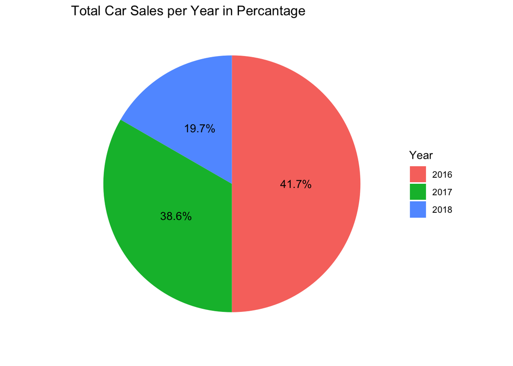

```r
   raw_data %>%
   filter(auto_total > 0 & comm_total > 0) %>%
   select(brand_name,auto_total,comm_total,total_total,year) %>%
   arrange(desc(year),desc(total_total)) %>%
   group_by(brand_name, year) %>%
   summarize(year_total = sum(total_total)) %>%
   arrange(desc(year_total)) %>%
   group_by(year) %>%
   summarize(year_total2 = sum(year_total)) %>%
   mutate(prop=percent(year_total2 / sum(year_total2))) %>%
   ggplot(data = ., aes(x="", y=prop, fill=as.character(year)))+ labs(x = "", y = "", title = "Total Car Sales per Year in Percantage") +
   geom_bar(width = 1, stat = "identity") + coord_polar("y", start=0) +
   theme(plot.title=element_text(hjust=0.5,face='bold',size=16)) +
   theme_classic() + theme(axis.line = element_blank(), axis.text = element_blank(), axis.ticks = element_blank()) +
   geom_text(aes(label=prop),position=position_stack(vjust = 0.5)) +  guides(fill=guide_legend(title="Year"))
```